# Modeling and prediction for movies

Author: TOSHAN MAJUMDAR

Time: MARCH, 2019

### **OFFICIAL DESCRIPTION:**

IMDB(Internet movie database):

IMDb (Internet Movie Database) is an online database of information related to films, television programs, home videos and video games, and internet streams, including cast, production crew and personnel biographies, plot summaries, trivia, and fan reviews and ratings. An additional fan feature, message boards, was abandoned in February 2017. Originally a fan-operated website, the database is owned and operated by IMDb.com, Inc., a subsidiary of Amazon.

As of October 2018, IMDb has approximately 5.3 million titles (including episodes) and 9.3 million personalities in its database, as well as 83 million registered users.

SOURCE: https://en.wikipedia.org/wiki/IMDb

IMDB OFFCIAL LINK: https://www.imdb.com/

ROTTEN TOMATOES:

Rotten Tomatoes and the TomatometerT rating is the most trusted measurement of quality entertainment. As the leading online aggregator of movie and TV show reviews from professional critics, Rotten Tomatoes offers the most comprehensive guide to what’s fresh. The world famous TomatometerT rating represents the percentage of positive professional reviews for films and TV shows and is used by millions every day, to help with their entertainment viewing decisions.

The Tomatometer score represents the percentage of professional critic reviews that are positive for a given film or television show. A Tomatometer score is calculated for a movie or TV show after it receives at least five reviews:

1. When at least 60% of reviews for a movie or TV show are positive, a red tomato is displayed to indicate its Fresh status.
2. When less than 60% of reviews for a movie or TV show are positive, a green splat is displayed to indicate its Rotten status.

ROTTEN TOMATOES OFFICIAL LINK: https://www.rottentomatoes.com/

OSCARS:

The Academy Awards, also known as the Oscars, are a set of awards for artistic and technical merit in the film industry, given annually by the Academy of Motion Picture Arts and Sciences (AMPAS), to recognize excellence in cinematic achievements as assessed by the Academy’s voting membership. The various category winners are awarded a copy of a golden statuette, officially called the “Academy Award of Merit”, although more commonly referred to by its nickname “Oscar”. The Academy Awards ceremony was first broadcast on radio in 1930 and televised for the first time in 1953. It is the oldest worldwide entertainment awards ceremony and is now seen live worldwide.A total of 3,072 Oscar statuettes have been awarded from the inception of the award through the 90th ceremony.

SOURCE: https://en.wikipedia.org/wiki/Academy_Awards

ACADEMY AWARDS OFFICIAL LINK: https://oscar.go.com/

### **CAUSALITY/GENERIZABILITY:**

The data set:**movies.Rdata** contains information(32 variables) about 651 movies with each row of the dataset representing an individual maovie and each column representing the descriptive variable regarding the movie, eg:release date, genre, runtime, etc. The dataset is a collection of movies from 1970 to 2014 and since the total number of movies produced in that time is 9962( according to imdb sources) the sample size(651) is less than 10% of the total population of movies and thus can be considered random sampling. Since the dataset is an observational study, any strong assosiation among variables can only be considered as correlations and not as causations.

## Setup

### Load packages

```r
rm(list=ls()) #remove previous variables
library(knitr)
library(ggplot2)
library(dplyr)
library(statsr)
library(olsrr) # regression model selection
library(gridExtra) #plotting grid layout of graphs
```

### Load data

```r
load("movies.Rdata")
```

## Part 1: Data

```r
data<-movies
dim(data)
```

```
## [1] 651  32
```

```r
str(data)
```

```
## Classes 'tbl_df', 'tbl' and 'data.frame':    651 obs. of  32 variables:
##  $ title           : chr  "Filly Brown" "The Dish" "Waiting for Guffman" "The Age of Innocence" ...
##  $ title_type      : Factor w/ 3 levels "Documentary",..: 2 2 2 2 2 1 2 2 1 2 ...
##  $ genre           : Factor w/ 11 levels "Action & Adventure",..: 6 6 4 6 7 5 6 6 5 6 ...
##  $ runtime         : num  80 101 84 139 90 78 142 93 88 119 ...
##  $ mpaa_rating     : Factor w/ 6 levels "G","NC-17","PG",..: 5 4 5 3 5 6 4 5 6 6 ...
##  $ studio          : Factor w/ 211 levels "20th Century Fox",..: 91 202 167 34 13 163 147 118 88 84 ...
##  $ thtr_rel_year   : num  2013 2001 1996 1993 2004 ...
##  $ thtr_rel_month  : num  4 3 8 10 9 1 1 11 9 3 ...
##  $ thtr_rel_day    : num  19 14 21 1 10 15 1 8 7 2 ...
##  $ dvd_rel_year    : num  2013 2001 2001 2001 2005 ...
##  $ dvd_rel_month   : num  7 8 8 11 4 4 2 3 1 8 ...
##  $ dvd_rel_day     : num  30 28 21 6 19 20 18 2 21 14 ...
##  $ imdb_rating     : num  5.5 7.3 7.6 7.2 5.1 7.8 7.2 5.5 7.5 6.6 ...
##  $ imdb_num_votes  : int  899 12285 22381 35096 2386 333 5016 2272 880 12496 ...
```

[output cut: 18 more lines]

```r
## checking for column wise NA values
NAcounts <- colSums(is.na(data))
NAcounts
```

```
##            title       title_type            genre          runtime
##                0                0                0                1
##      mpaa_rating           studio    thtr_rel_year   thtr_rel_month
##                0                8                0                0
##     thtr_rel_day     dvd_rel_year    dvd_rel_month      dvd_rel_day
##                0                8                8                8
##      imdb_rating   imdb_num_votes   critics_rating    critics_score
##                0                0                0                0
##  audience_rating   audience_score     best_pic_nom     best_pic_win
##                0                0                0                0
##   best_actor_win best_actress_win     best_dir_win       top200_box
##                0                0                0                0
##         director           actor1           actor2           actor3
##                2                2                7                9
##           actor4           actor5         imdb_url           rt_url
##               13               15                0                0
```

As we can see the dataset: movies.Rdata contains information of around 651 movies in the form of 32 variables with each row representing a movie and each column representing a desrciption regarding the movie.

Most of the NA values seem to be concentrated in the variables regarding the actor names**(actor1,actor2,actor3,….)** and DVD release information**(dvd_release_yr,dvd_release_month)**

```r
#distribution of different types of variables in dataset:movies

my.class <- sapply(data, class)
n<-sum(my.class=="numeric")
i<-sum(my.class=="integer")
f<-sum(my.class=="factor")
cat("NUMERICAL VARIABLES:",n)
cat("\nINTEGER VARIABLES:",i)
cat("\nCATEGORICAL VARIABLES:",f)
```

```
## NUMERICAL VARIABLES: 10
## INTEGER VARIABLES: 1
## CATEGORICAL VARIABLES: 12
```

The data seems to be equally divided among categorical and numerical variables

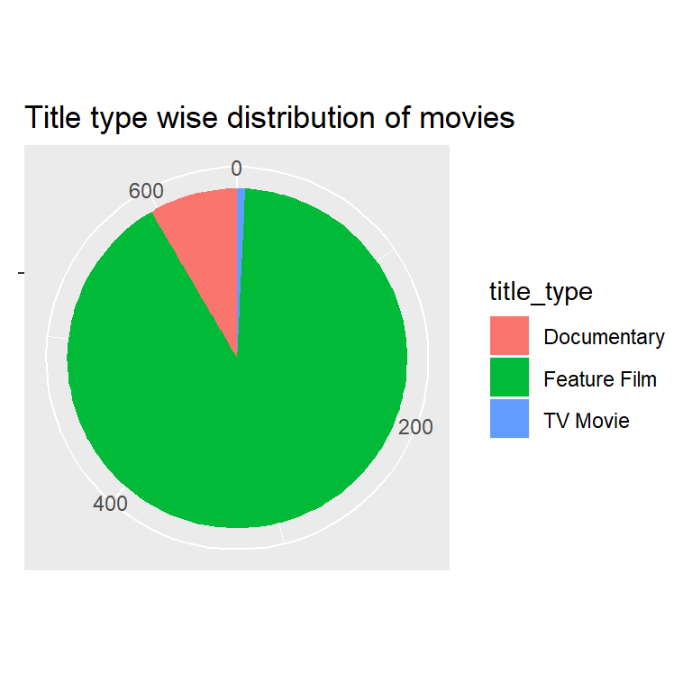

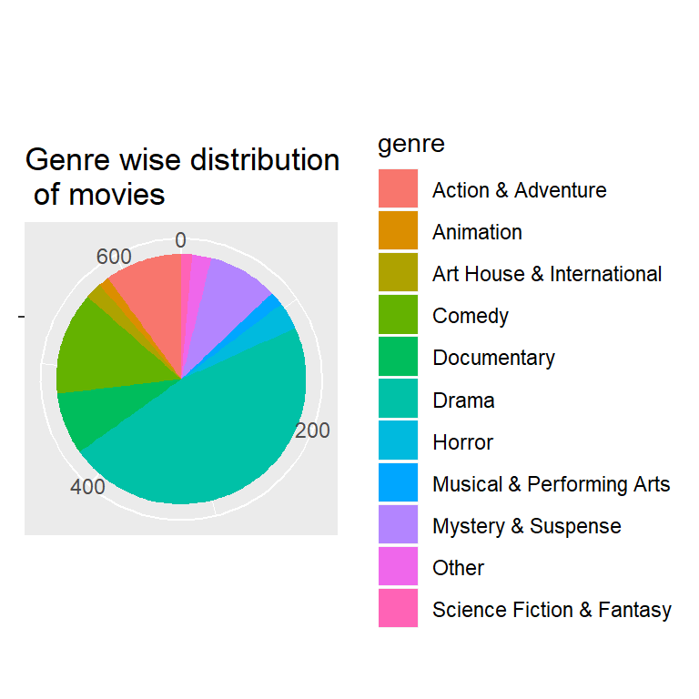

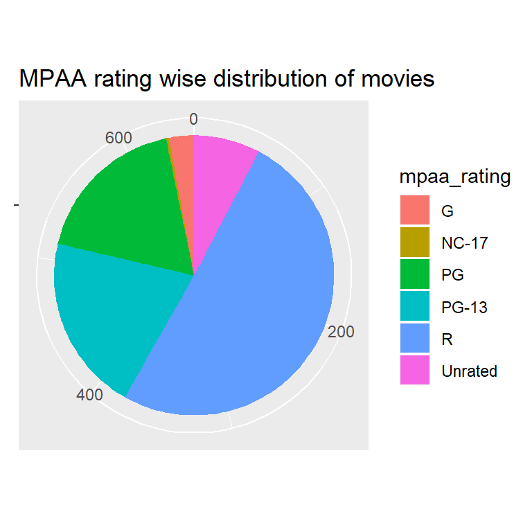

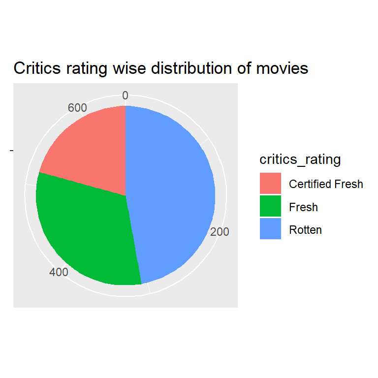

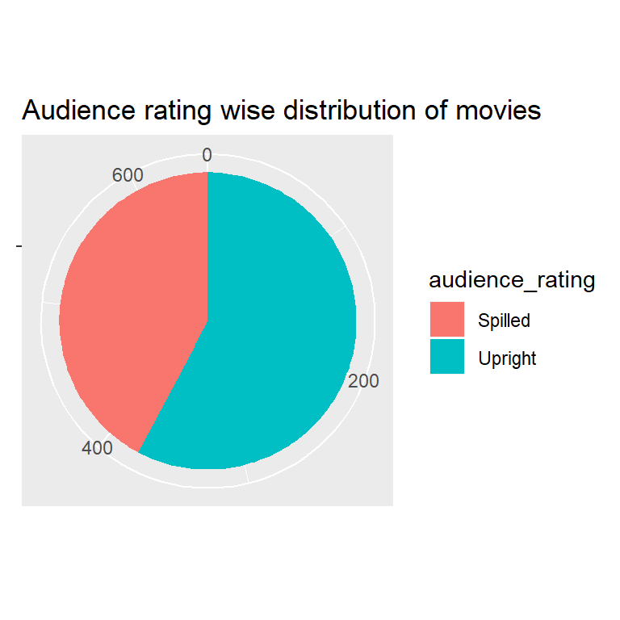

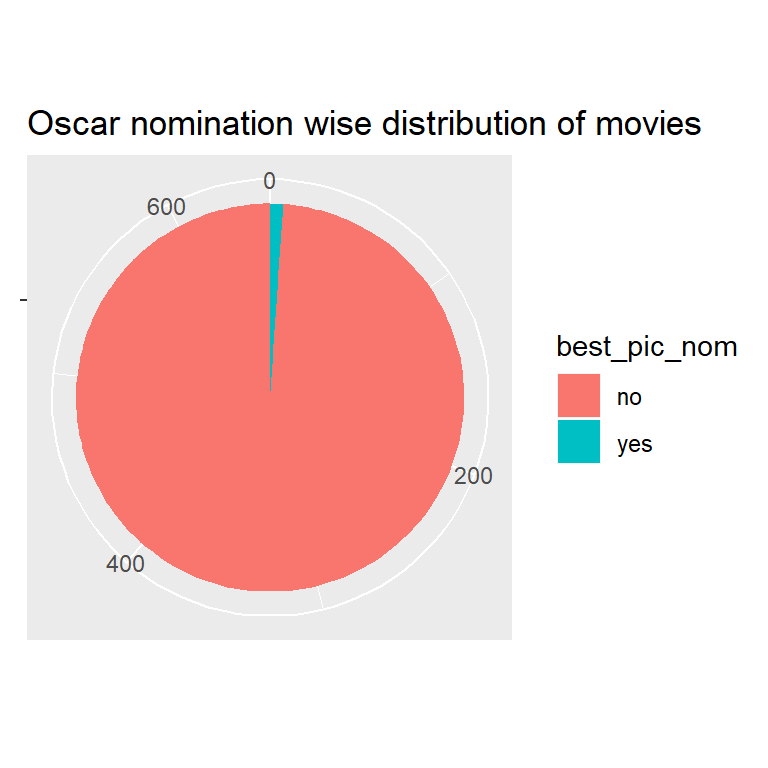

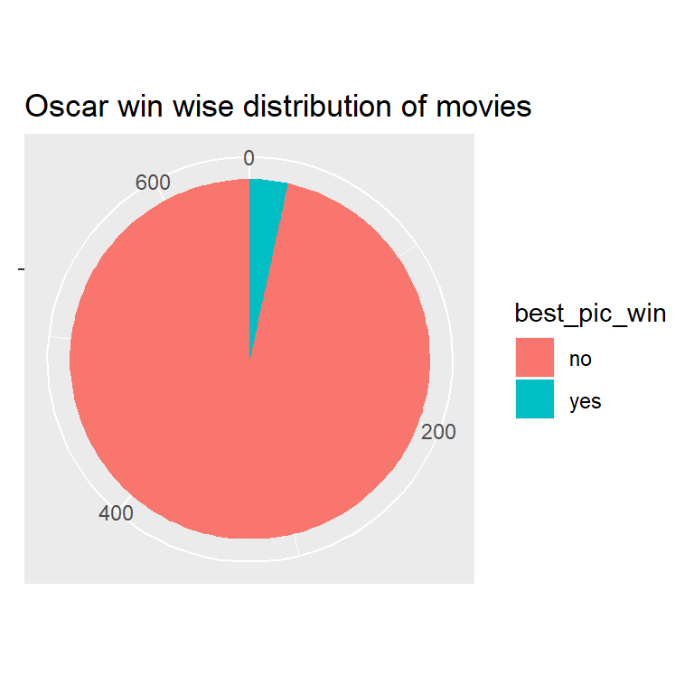

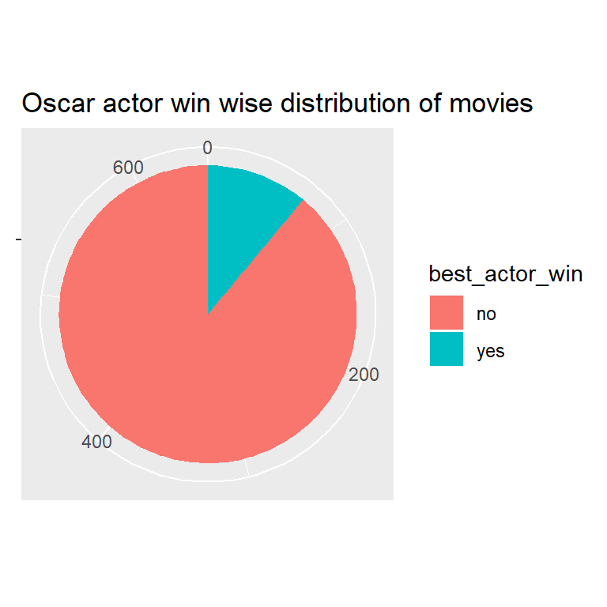

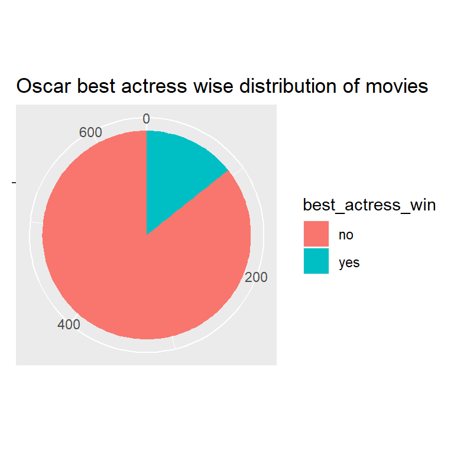

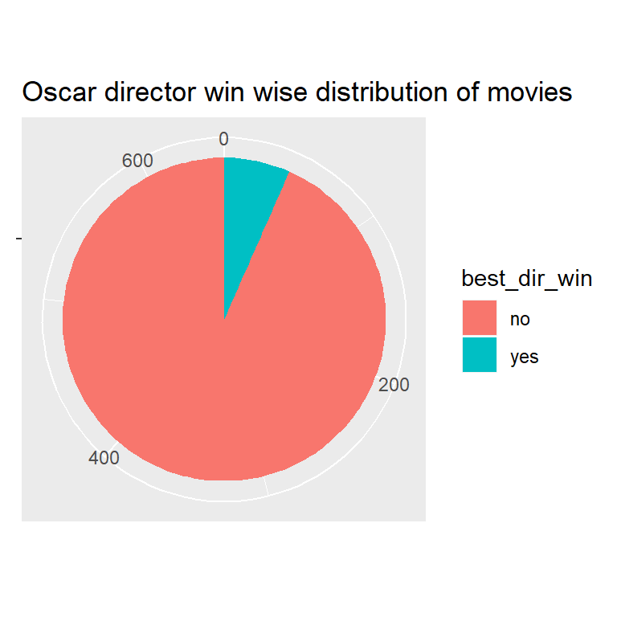

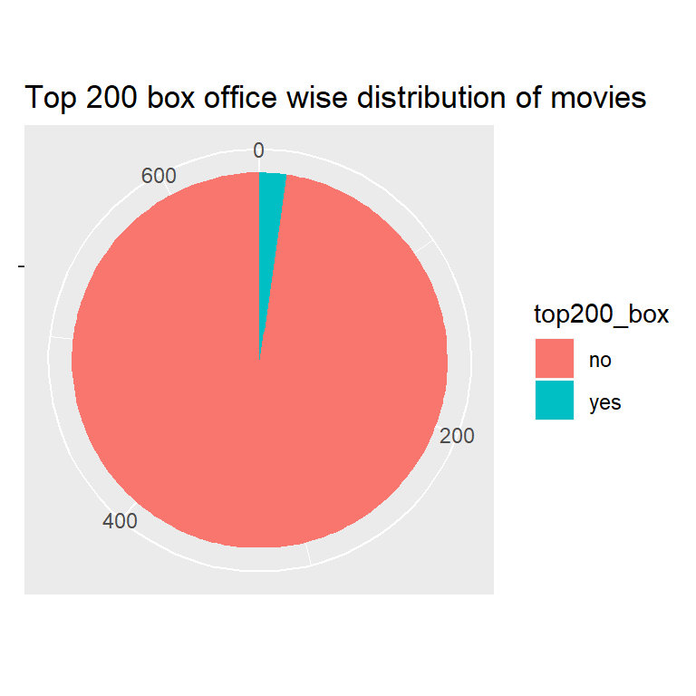

```r
#distribution of various values among variables in dataset

temp1<-as.data.frame(count(data,data$title_type))
p1<-ggplot(temp1 ) %>%
+geom_bar(stat="identity", aes( x="" , y=temp1$n, fill=temp1$'data$title_type')) %>%
+coord_polar("y") %>%
+labs(x=NULL,y=NULL,fill='title_type',title='Title type wise distribution of movies')
p1
temp2<-as.data.frame(count(data,data$genre))
p2<-ggplot(temp2 ) %>%
+geom_bar(stat="identity", aes( x="" , y=temp2$n, fill=temp2$'data$genre')) %>%
+coord_polar("y") %>%
+labs(x=NULL,y=NULL,fill='genre',title='Genre wise distribution \n of movies')
p2
temp3<-as.data.frame(count(data,data$mpaa_rating))
p3<-ggplot(temp3) %>%
+geom_bar(stat="identity", aes( x="" , y=temp3$n, fill=temp3$'data$mpaa_rating') ) %>%
+coord_polar("y") %>%
+labs(x=NULL,y=NULL,fill='mpaa_rating',title='MPAA rating wise distribution of movies')
p3
temp4<-as.data.frame(count(data,data$critics_rating))
p4<-ggplot(temp4) %>%
+geom_bar(stat="identity", aes( x="" , y=temp4$n, fill=temp4$'data$critics_rating') ) %>%
+coord_polar("y") %>%
+labs(x=NULL,y=NULL,fill='critics_rating',title='Critics rating wise distribution of movies')
p4
temp5<-as.data.frame(count(data,data$audience_rating))
p5<-ggplot(temp5)  %>%
+geom_bar(stat="identity", aes( x="" , y=temp5$n, fill=temp5$'data$audience_rating') ) %>%
+coord_polar("y") %>%
+labs(x=NULL,y=NULL,fill='audience_rating',title='Audience rating wise distribution of movies')
p5
temp6<-as.data.frame(count(data,data$best_pic_win))
p6<-ggplot(temp6) %>%
+geom_bar(stat="identity", aes( x="" , y=temp6$n, fill=temp6$'data$best_pic_win')) %>%
+coord_polar("y") %>%
+labs(x=NULL,y=NULL,fill='best_pic_nom',title='Oscar nomination wise distribution of movies')
p6
temp7<-as.data.frame(count(data,data$best_pic_nom))
p7<-ggplot(temp7 ) %>%
+geom_bar(stat="identity", aes( x="" , y=temp7$n, fill=temp7$'data$best_pic_nom')) %>%
+coord_polar("y") %>%
+labs(x=NULL,y=NULL,fill='best_pic_win',title='Oscar win wise distribution of movies')
p7
temp8<-as.data.frame(count(data,data$best_actress_win))
p8<-ggplot(temp8) %>%
+geom_bar(stat="identity", aes( x="" , y=temp8$n, fill=temp8$'data$best_actress_win') ) %>%
+coord_polar("y") %>%
+labs(x=NULL,y=NULL,fill='best_actor_win',title='Oscar actor win wise distribution of movies')
p8
temp9<-as.data.frame(count(data,data$best_actor_win))
p9<-ggplot(temp9) %>%
+geom_bar(stat="identity", aes( x="" , y=temp9$n, fill=temp9$'data$best_actor_win') ) %>%
+coord_polar("y") %>%
+labs(x=NULL,y=NULL,fill='best_actress_win',title='Oscar best actress wise distribution of movies')
p9
temp10<-as.data.frame(count(data,data$best_dir_win))
p10<-ggplot(temp10) %>%
+geom_bar(stat="identity", aes( x="" , y=temp10$n, fill=temp10$'data$best_dir_win') ) %>%
+coord_polar("y") %>%
+labs(x=NULL,y=NULL,fill='best_dir_win',title='Oscar director win wise distribution of movies')
p10
temp11<-as.data.frame(count(data,data$top200_box))
p11<-ggplot(temp11) %>%
+geom_bar(stat="identity", aes( x="" , y=temp11$n, fill=temp11$'data$top200_box') ) %>%
+coord_polar("y") %>%
+labs(x=NULL,y=NULL,fill='top200_box',title='Top 200 box office wise distribution of movies')
p11
```

## Part 2: Research question

**RQ: When the production house receives the final cut of a movie to be distribution in theatres, can it decide the box office performance of the movie based only on the characteristics of the movie ? : genre,cast,movie type, rating**

Since I am assuming the movie has not yet released when it comes to the production house for distribution, variables such as release date, DVD sales, critics and audience ratings would not be there. Therefore I have not taken such variables into consideration during my data analysis.

I am interested in the research question in order develop a rough predictor of box office performance based on the movie characteristics which could help production companies in deciding which movies to select for theatre distribution as well as to aid individuals in their movie consumption choices.

## Part 3: Exploratory data analysis

```r
g0<-ggplot(data, aes(imdb_rating))+geom_density(size=1)+labs(title="Distribution of imdb ratings")
g0
summary(data$imdb_rating)
```

```
##    Min. 1st Qu.  Median    Mean 3rd Qu.    Max.
##   1.900   5.900   6.600   6.493   7.300   9.000
```

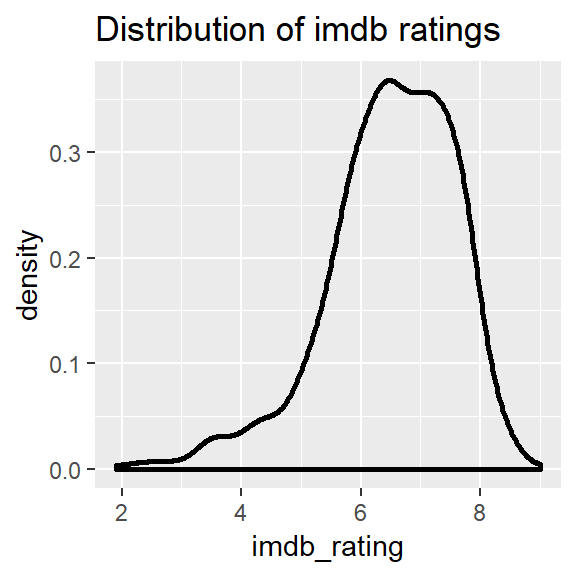

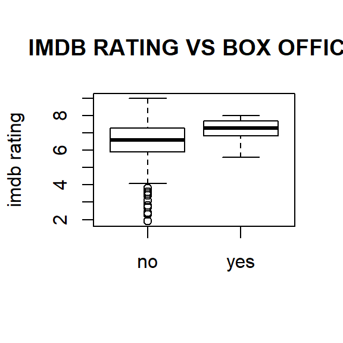

```r
boxplot(imdb_rating~top200_box,data=data,main="IMDB RATING VS BOX OFFICE",ylab = "imdb rating")
```

The imdb rating distriution is left skewed with most of the values lying between 6 to 8 rating.By seeing the boxplot of imdb rating and box office performance, we notice that the imdb ratings of movies in the top 200 box office are slightly higher than those which did not manage to reach the top 200. Hence to prove an assoisation between imdb ratings and BO performance we can do an inference test. Proving the hypothesis:( **Ha– IMD RATING(top_200_BO) > IMDB RATING(BO)** ) could be useful as we can treat imdb rating as a precitor for box office success and use it further in our regression analysis since **imdb_rating** is a numerical variable(easier to use) as compared to **top_200** which is a categorical variable.

```r
#Checking imdb_score as proxy for box office performance
inference(y = imdb_rating, x =top200_box, data =data, statistic = "mean", type = "ht", null = 0, alternative = "less", method = "theoretical")
```

```
## Response variable: numerical
## Explanatory variable: categorical (2 levels)
## n_no = 636, y_bar_no = 6.4778, s_no = 1.088
## n_yes = 15, y_bar_yes = 7.14, s_yes = 0.6916
## H0: mu_no =  mu_yes
## HA: mu_no < mu_yes
## t = -3.6046, df = 14
## p_value = 0.0014
```

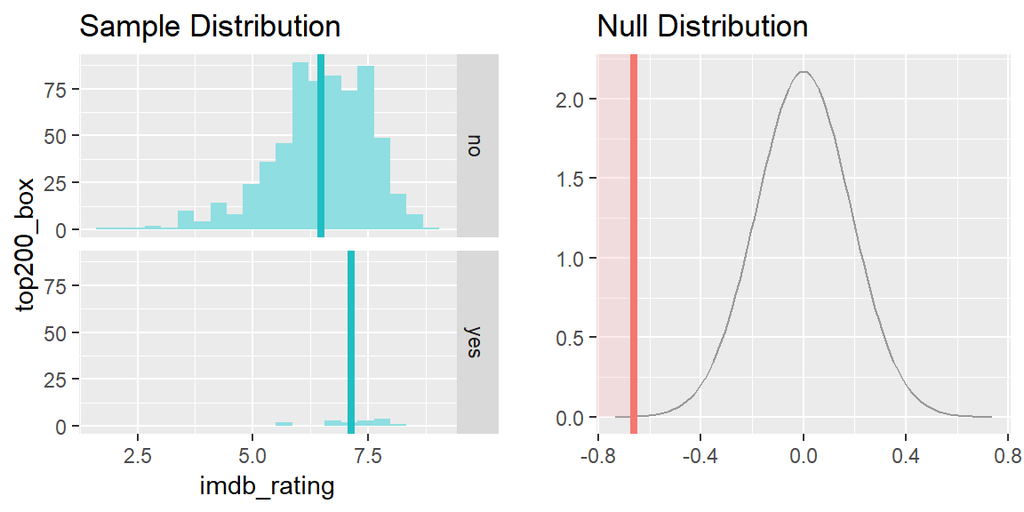

Th inference test for hypothesis:**Ha– IMD RATING(top_200_BO) > IMDB RATING(BO)** has generated a significant **p value(0.0014)** which means we can treat the variable: **imdb_rating** as a significant predictor for box office success. We will use this conclusion in the remiander of the data analysis.

```r
#selecting relevant variables from main dataset into data sub set: movies
movies<-subset(data,select=c(title_type,genre,mpaa_rating,imdb_rating,best_actor_win,best_actress_win,best_dir_win))

#checking NA values in data subset
NAcounts <- colSums(is.na(movies))
NAcounts
```

```
##       title_type            genre      mpaa_rating      imdb_rating
##                0                0                0                0
##   best_actor_win best_actress_win     best_dir_win
##                0                0                0
```

There are **no NA values** in the new dataset:movies which means that no data cleaning is required. This fortunate result has come since the data anlaysis is not dependent on variables which have most NA values in the parent dataset: actors names, DVD information

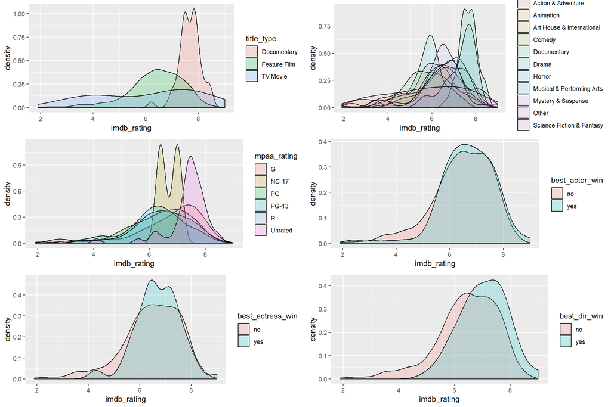

```r
#Distribution of individual variables with imdb score:
g1<-ggplot(movies, aes(imdb_rating, fill = title_type))+geom_density(alpha = 0.2)
g2<-ggplot(movies, aes(imdb_rating, fill = genre))+geom_density(alpha = 0.1)
g3<-ggplot(movies, aes(imdb_rating, fill = mpaa_rating))+geom_density(alpha = 0.2)
g4<-ggplot(movies, aes(imdb_rating, fill = best_actor_win))+geom_density(alpha = 0.2)
g5<-ggplot(movies, aes(imdb_rating, fill = best_actress_win))+geom_density(alpha = 0.2)
g6<-ggplot(movies, aes(imdb_rating, fill = best_dir_win))+geom_density(alpha = 0.2)
grid.arrange( g1, g2, g3, g4, g5,g6,ncol = 2)
```

## Part 4: Modeling

I have used the following variables:**title_type,genre,mpaa_rating,best_actor_win,best_actress_win,best_dir_win** to predict the future **imdb_rating** of movies. I have excluded the other variable from regression analysis since those details regarding the movie(DVD info, critics,audience rating,oscar win/nomination for movie) would not be avaialble before the movie released.Thus I have selected only those movies whose details will be available with the production house before the movie’s release. The future **imdb_rating** of the movie is assosiated to its box office success, proved earlier through inference testing.

```r
#constructing multiple regression model:
model<-lm( imdb_rating ~ title_type + genre + mpaa_rating + best_actor_win + best_actress_win + best_dir_win, movies)
summary(model)
```

```
##
## Call:
## lm(formula = imdb_rating ~ title_type + genre + mpaa_rating +
##     best_actor_win + best_actress_win + best_dir_win, data = movies)
##
## Residuals:
##     Min      1Q  Median      3Q     Max
## -3.8453 -0.4822  0.0351  0.6188  2.1178
##
## Coefficients:
##                                Estimate Std. Error t value Pr(>|t|)
## (Intercept)                      7.2590     0.4269  17.006  < 2e-16 ***
## title_typeFeature Film          -0.8017     0.3471  -2.310  0.02123 *
## title_typeTV Movie              -1.5214     0.5462  -2.785  0.00551 **
## genreAnimation                  -0.4029     0.3651  -1.103  0.27025
## genreArt House & International   0.5887     0.2830   2.080  0.03795 *
## genreComedy                     -0.2039     0.1555  -1.311  0.19033
## genreDocumentary                 0.7862     0.3721   2.113  0.03502 *
## genreDrama                       0.6594     0.1329   4.962 9.00e-07 ***
## genreHorror                     -0.2553     0.2324  -1.098  0.27243
## genreMusical & Performing Arts   1.0030     0.3171   3.163  0.00164 **
## genreMystery & Suspense          0.4108     0.1747   2.352  0.01898 *
## genreOther                       0.6702     0.2643   2.535  0.01147 *
## genreScience Fiction & Fantasy  -0.2851     0.3337  -0.854  0.39332
## mpaa_ratingNC-17                -0.4827     0.7106  -0.679  0.49724
## mpaa_ratingPG                   -0.5714     0.2568  -2.225  0.02643 *
## mpaa_ratingPG-13                -0.7345     0.2608  -2.816  0.00501 **
## mpaa_ratingR                    -0.4761     0.2539  -1.875  0.06127 .
## mpaa_ratingUnrated              -0.2803     0.2920  -0.960  0.33737
## best_actor_winyes                0.1320     0.1087   1.215  0.22470
## best_actress_winyes              0.1931     0.1208   1.598  0.11055
## best_dir_winyes                  0.6034     0.1500   4.024 6.43e-05 ***
## ---
## Signif. codes:  0 '***' 0.001 '**' 0.01 '*' 0.05 '.' 0.1 ' ' 1
##
## Residual standard error: 0.9364 on 630 degrees of freedom
## Multiple R-squared:  0.2777, Adjusted R-squared:  0.2548
## F-statistic: 12.11 on 20 and 630 DF,  p-value: < 2.2e-16
```

```r
#Backward Elimination (p-values)
ols_step_backward_p(model)
```

```
## Backward Elimination Method
## ---------------------------
##
## Candidate Terms:
##
## 1 . title_type
## 2 . genre
## 3 . mpaa_rating
## 4 . best_actor_win
## 5 . best_actress_win
## 6 . best_dir_win
##
## We are eliminating variables based on p value...
##
## Variables Removed:
##
##
## No more variables satisfy the condition of p value = 0.3
##
##
## Final Model Output
## ------------------
##
##                         Model Summary
## --------------------------------------------------------------
## R                       0.527       RMSE                0.936
## R-Squared               0.278       Coef. Var          14.422
## Adj. R-Squared          0.255       MSE                 0.877
## Pred R-Squared          0.215       MAE                 0.703
## --------------------------------------------------------------
##  RMSE: Root Mean Square Error
##  MSE: Mean Square Error
##  MAE: Mean Absolute Error
##
##                                ANOVA
## --------------------------------------------------------------------
##                Sum of
##               Squares         DF    Mean Square      F         Sig.
## --------------------------------------------------------------------
## Regression    212.382         20         10.619     12.11    0.0000
```

[output cut: 15 more lines]

```
##                     genreDrama     0.659         0.133        0.304     4.962    0.000     0.398     0.920
##                    genreHorror    -0.255         0.232       -0.043    -1.098    0.272    -0.712     0.201
## genreMusical & Performing Arts     1.003         0.317        0.124     3.163    0.002     0.380     1.626
##        genreMystery & Suspense     0.411         0.175        0.109     2.352    0.019     0.068     0.754
##                     genreOther     0.670         0.264        0.096     2.535    0.011     0.151     1.189
## genreScience Fiction & Fantasy    -0.285         0.334       -0.031    -0.854    0.393    -0.940     0.370
##               mpaa_ratingNC-17    -0.483         0.711       -0.025    -0.679    0.497    -1.878     0.913
##                  mpaa_ratingPG    -0.571         0.257       -0.203    -2.225    0.026    -1.076    -0.067
##               mpaa_ratingPG-13    -0.734         0.261       -0.273    -2.816    0.005    -1.247    -0.222
##                   mpaa_ratingR    -0.476         0.254       -0.220    -1.875    0.061    -0.975     0.023
##             mpaa_ratingUnrated    -0.280         0.292       -0.069    -0.960    0.337    -0.854     0.293
##              best_actor_winyes     0.132         0.109        0.043     1.215    0.225    -0.081     0.345
##            best_actress_winyes     0.193         0.121        0.056     1.598    0.111    -0.044     0.430
##                best_dir_winyes     0.603         0.150        0.138     4.024    0.000     0.309     0.898
## -----------------------------------------------------------------------------------------------------------
```

```
## [1] "No variables have been removed from the model."
```

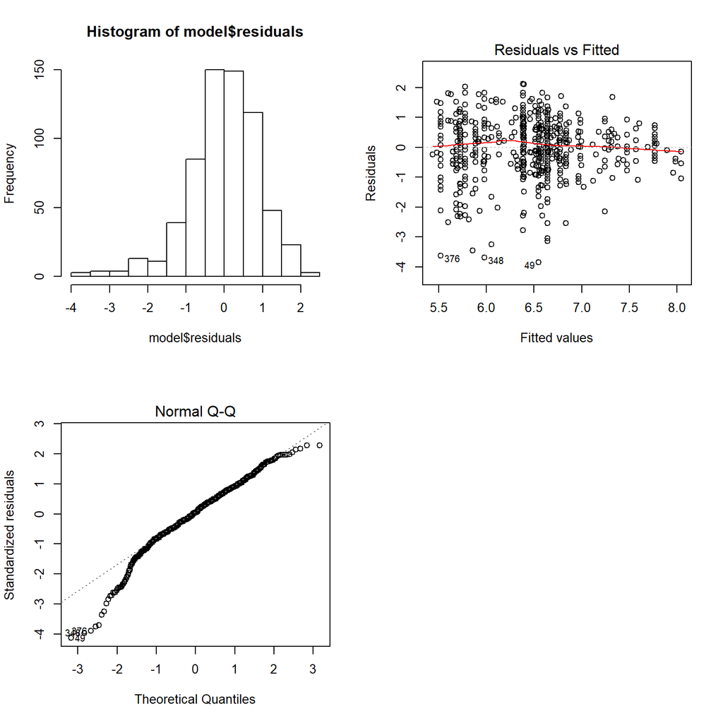

```r
#Model Check:

par(mfrow = c(2,2))
hist(model$residuals)
plot(model,which=1)
plot(model,which=2)
```

## Part 5: Prediction

```r
moonlight<-data.frame(title_type='Feature Film',genre='Drama',mpaa_rating='R',best_actor_win='yes',best_actress_win='no',best_dir_win='yes')

predict(model,moonlight,interval="prediction",level=0.95)
```

```
##        fit      lwr      upr
## 1 7.375983 5.506013 9.245953
```

For prediction we tried to predict the imdb_rating of the movie:**Moonlight** which released in 2016 and is not part of the dataset.

The actual rating: **7.4** and the predicted rating: **7.37** with error: **0.03**

The confidence interval of the priction for **imdb_rating**: [actual-1.87 , actual+1.87]

## Part 6: Conclusion

We selected appropriate variables from the main dataset which would be accesible to the production houses before a film’s release. Based on those variables we created a prediction model for predicting the future box office success of the movies(based on its imdb rating). Since most of the variables were categorical, the R squared value was not very high casting doubts on the predictability of the model. However we tested the model with a movie from 2016,and the model ws able to predict its imdb rating with an impressive error of 0.03. In conclusion,**even though there is an assosiation between box office rank and imdb rating, it is difficult to predict the popularity of a movie before it is released in theatres.**

A better predictive model can be constructed by taking the following points into consideration:

1. Include **more descriptive variables** regarding movie details. The given dataset is pretty skewed in relation to title_type with Feature films as a clear majority(>50%) and genre with drama (50%). The dataset:movies.RData contains only 32 variables out of which there are some ones which are not helpful for data analysis like: URLs of rotten tomatoes and IMDB.
2. Create new features from existing features by **converting categorical variables to numerical variables** utilising some sort of weighing rules. The larger the number of numerial variables in the dataset, the better the prediction.
3. Selecting predictors which are **good causal variables for the predicted variable**. This requires real world knowledge of the dataset( here it is movie industry ) to know which characteristics of individual movies are reponsible for its popularity/ box office success. Selecting models based on adjusted R sqaured or p-values does not ensure that the parsimonious model has good predictive power in all cases. The model may also fail when it encounters datasets with diiferent distributions of variables.